# Generalization

INFO 521 · Module 2 · Lecture B — Bias-Variance & Regularization

Greg Chism

College of Information Science · University of Arizona

August 2026

## Learning outcomes

By the end of Lecture B you should be able to:

1. **Explain the bias-variance decomposition** of expected test error.
2. **State the tradeoff** and connect it to the U-curve.
3. **Derive and apply ridge regression**, and **tune $\lambda$ by CV**.
4. **Connect ridge to the Module 1 uniqueness condition.**

## Recap: the U, and why

Lecture A: test error is **U-shaped** in complexity — underfit on the left, overfit on the right.

Cross-validation told us *where* the bottom is. **Now: why is there a U at all?**

## Bias and variance, intuitively

Imagine refitting on **many datasets** drawn the same way:

- **Bias** — the *systematic* miss: even on average, a too-simple model can’t reach the truth.
- **Variance** — the *sensitivity*: a too-flexible model swings wildly from one dataset to the next.

## Bias and variance on the data

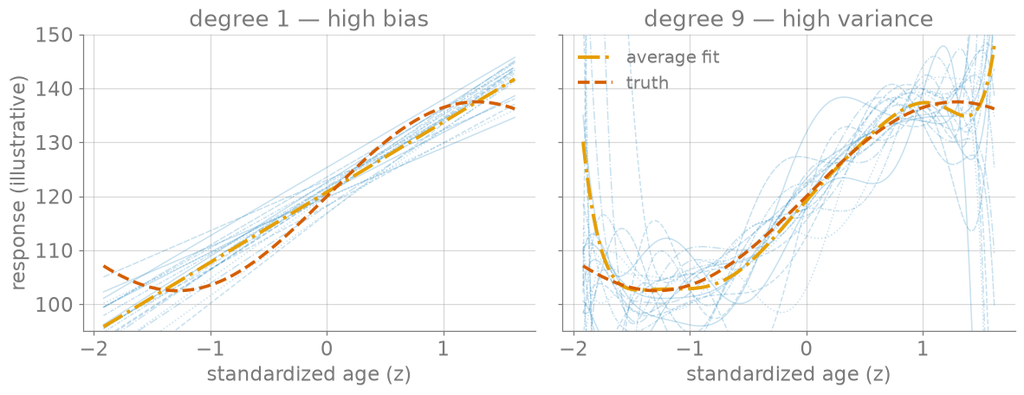

Figure 1: Repeated fits: degree 1 (biased, tight) vs. degree 9 (low-bias, high-variance).

## The decomposition

For a fixed input $\mathbf{x}$, expected test error splits into three pieces:

$$\mathbb{E}\bigl[(y - \hat{f}(\mathbf{x}))^2\bigr]
\;=\;
\underbrace{\text{bias}^2}_{\text{systematic}}
\;+\;
\underbrace{\text{variance}}_{\text{sensitivity}}
\;+\;
\underbrace{\sigma^2}_{\text{irreducible}} .$$

The $\sigma^2$ floor is noise no model can beat. Full derivation → appendix-bias-variance.html.

## The tradeoff

As complexity rises:

- **bias$^2$ falls** — the model can represent more;
- **variance rises** — the model chases the sample;
- their **sum is the U**, resting on the irreducible $\sigma^2$ floor.

The best model is not the most flexible one — it is the one that **balances** the two.

# Controlling the tradeoff: regularization.

## Ridge regression

Add a penalty on the size of the weights:

$$\mathcal{L}_{\text{ridge}}(\mathbf{w}) = \lVert \mathbf{y} - \mathbf{X}\mathbf{w}\rVert_2^2 + \lambda\lVert \mathbf{w}\rVert_2^2 .$$

*(The intercept $w_0$ is not penalized — the code centers instead. We also drop the $1/N$ here; it only rescales $\lambda$.)*

- $\lambda = 0$ → ordinary least squares.
- $\lambda > 0$ → shrinks weights toward $\mathbf{0}$, **trading a little bias for less variance**.

## Ridge: the closed form

The penalty just adds $\lambda\mathbf{I}$ inside the normal equations:

$$\boxed{\;\hat{\mathbf{w}}_{\text{ridge}} = \left(\mathbf{X}^{\!\top}\mathbf{X} + \lambda\mathbf{I}\right)^{-1}\mathbf{X}^{\!\top}\mathbf{y}\;}$$

$\mathbf{X}^{\!\top}\mathbf{X} + \lambda\mathbf{I}$ is **positive definite for any $\lambda>0$** — so it is *always* invertible. Ridge **guarantees** the unique solution that Module 1 needed full column rank for.

## The coefficient path

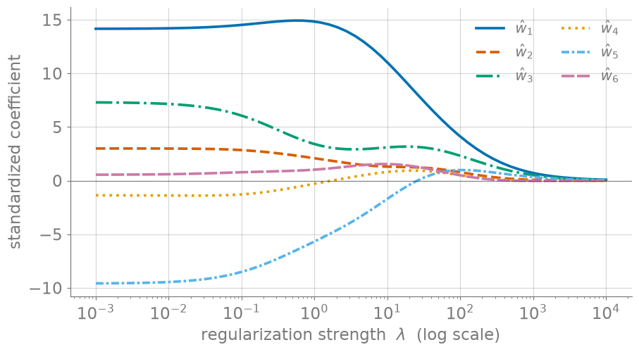

Figure 2: Ridge shrinks every coefficient toward 0 as λ grows (log-λ axis).

## The two limits

- $\lambda \to 0$: the penalty vanishes — **ridge recovers OLS** ($\hat{\mathbf{w}}$ from Module 1). Maximum variance, minimum bias.
- $\lambda \to \infty$: the penalty dominates — **$\hat{\mathbf{w}} \to \mathbf{0}$**, the model predicts a constant. Maximum bias, minimum variance.

The useful $\lambda$ lives in between — found by cross-validation.

## Choosing λ by cross-validation

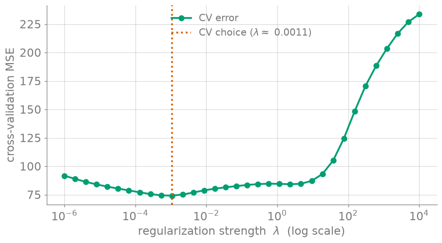

Figure 3: 5-fold CV error vs. λ for a degree-14 ridge fit; the minimum is the CV choice.

## Live demo: bias-variance / ridge explorer

Slide $\lambda$ — watch bias trade against variance as the fit stiffens, live on this slide.

## Explorer — static fallback

*The iframe above does not print or export to PDF; this snapshot stands in.*

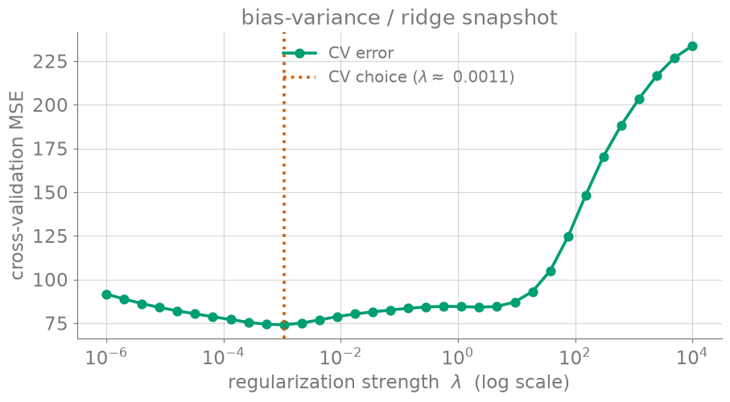

Figure 4: Static fallback: CV error vs. λ (used in print / PDF).

## Forward hook

The ridge penalty $\lambda\lVert\mathbf{w}\rVert_2^2$ is secretly a **Gaussian prior** on $\mathbf{w}$: ridge is **MAP estimation** under that prior. We derive that in **Module 4.**

So “shrink the weights” and “believe, a priori, the weights are small” are the same statement — one more object doing double duty across the term.

## Recap

- **Bias-variance** — test error $=$ bias$^2$ $+$ variance $+\ \sigma^2$; the U is their sum.
- **Ridge** — $\mathcal{L}+\lambda\lVert\mathbf{w}\rVert^2$, closed form $\hat{\mathbf{w}}_{\text{ridge}}=(\mathbf{X}^{\!\top}\mathbf{X}+\lambda\mathbf{I})^{-1}\mathbf{X}^{\!\top}\mathbf{y}$; always invertible (intercept not penalized; the dropped $1/N$ only rescales $\lambda$).
- **Tune $\lambda$ by CV** — the knob that balances the tradeoff.

Module 2 has no standalone checkpoint; generalization discipline is assessed through your modeling choices in **Part 1**.